# Project: Investigate a Dataset - tmdb-movies

- Introduction
- Data Wrangling
- Exploratory Data Analysis
- Conclusions

## Introduction

### Dataset Description

> This data set contains information about 10,000 movies collected from The Movie Database (TMDb), including user ratings and revenue.
> - Certain columns, like 'cast' and 'genres', contain multiple values separated by pipe (|) characters.
> - There are some odd characters in the 'cast' column. Don't worry about cleaning them. You can leave them as is.
> - The final two columns ending with "_adj" show the budget and revenue of the associated movie in terms of 2010 dollars, accounting for inflation over time.

## Libraries that were used

- pandas
- numpy
- matplotlib
- plotly

### Question(s) for Analysis

1. Which genres are most popular from year to year?
2. Film production growth by genre from 1960 to 2015
3. What year were the most films made?
4. Which director directed the most films from 1960 to 2015?
5. Which company produced the most films from 1960 to 2015?
6. Comparison between the average budget for the year and its profits
7. What is the relationship between movie popularity and revenue?

```python
import pandas as pd
import numpy as np
import matplotlib.pyplot as plt
import seaborn as sns
%matplotlib inline
import plotly.graph_objects as go
```

## Data Wrangling

### General Properties

```python
#Loading data and displaying the first five rows
df = pd.read_csv('./Database_TMDb_movie_data/tmdb-movies.csv', index_col = 'id')
df.head()
```

| id | imdb_id | popularity | budget | revenue | original_title | cast | homepage | director | tagline | keywords | overview | runtime | genres | production_companies | release_date | vote_count | vote_average | release_year | budget_adj | revenue_adj |
| --- | --- | --- | --- | --- | --- | --- | --- | --- | --- | --- | --- | --- | --- | --- | --- | --- | --- | --- | --- | --- |
| 135397 | tt0369610 | 32.985763 | 150000000 | 1513528810 | Jurassic World | Chris Pratt\|Bryce Dallas Howard\|Irrfan Khan\|Vi... | http://www.jurassicworld.com/ | Colin Trevorrow | The park is open. | monster\|dna\|tyrannosaurus rex\|velociraptor\|island | Twenty-two years after the events of Jurassic ... | 124 | Action\|Adventure\|Science Fiction\|Thriller | Universal Studios\|Amblin Entertainment\|Legenda... | 6/9/15 | 5562 | 6.5 | 2015 | 1.379999e+08 | 1.392446e+09 |
| 76341 | tt1392190 | 28.419936 | 150000000 | 378436354 | Mad Max: Fury Road | Tom Hardy\|Charlize Theron\|Hugh Keays-Byrne\|Nic... | http://www.madmaxmovie.com/ | George Miller | What a Lovely Day. | future\|chase\|post-apocalyptic\|dystopia\|australia | An apocalyptic story set in the furthest reach... | 120 | Action\|Adventure\|Science Fiction\|Thriller | Village Roadshow Pictures\|Kennedy Miller Produ... | 5/13/15 | 6185 | 7.1 | 2015 | 1.379999e+08 | 3.481613e+08 |
| 262500 | tt2908446 | 13.112507 | 110000000 | 295238201 | Insurgent | Shailene Woodley\|Theo James\|Kate Winslet\|Ansel... | http://www.thedivergentseries.movie/#insurgent | Robert Schwentke | One Choice Can Destroy You | based on novel\|revolution\|dystopia\|sequel\|dyst... | Beatrice Prior must confront her inner demons ... | 119 | Adventure\|Science Fiction\|Thriller | Summit Entertainment\|Mandeville Films\|Red Wago... | 3/18/15 | 2480 | 6.3 | 2015 | 1.012000e+08 | 2.716190e+08 |
| 140607 | tt2488496 | 11.173104 | 200000000 | 2068178225 | Star Wars: The Force Awakens | Harrison Ford\|Mark Hamill\|Carrie Fisher\|Adam D... | http://www.starwars.com/films/star-wars-episod... | J.J. Abrams | Every generation has a story. | android\|spaceship\|jedi\|space opera\|3d | Thirty years after defeating the Galactic Empi... | 136 | Action\|Adventure\|Science Fiction\|Fantasy | Lucasfilm\|Truenorth Productions\|Bad Robot | 12/15/15 | 5292 | 7.5 | 2015 | 1.839999e+08 | 1.902723e+09 |
| 168259 | tt2820852 | 9.335014 | 190000000 | 1506249360 | Furious 7 | Vin Diesel\|Paul Walker\|Jason Statham\|Michelle ... | http://www.furious7.com/ | James Wan | Vengeance Hits Home | car race\|speed\|revenge\|suspense\|car | Deckard Shaw seeks revenge against Dominic Tor... | 137 | Action\|Crime\|Thriller | Universal Pictures\|Original Film\|Media Rights ... | 4/1/15 | 2947 | 7.3 | 2015 | 1.747999e+08 | 1.385749e+09 |

```python
#Display the number of columns and rows
df.shape
```

```
(10866, 20)
```

```python
# Statistics summary
df.describe()
```

|  | popularity | budget | revenue | runtime | vote_count | vote_average | release_year | budget_adj | revenue_adj |
| --- | --- | --- | --- | --- | --- | --- | --- | --- | --- |
| count | 10866.000000 | 1.086600e+04 | 1.086600e+04 | 10866.000000 | 10866.000000 | 10866.000000 | 10866.000000 | 1.086600e+04 | 1.086600e+04 |
| mean | 0.646441 | 1.462570e+07 | 3.982332e+07 | 102.070863 | 217.389748 | 5.974922 | 2001.322658 | 1.755104e+07 | 5.136436e+07 |
| std | 1.000185 | 3.091321e+07 | 1.170035e+08 | 31.381405 | 575.619058 | 0.935142 | 12.812941 | 3.430616e+07 | 1.446325e+08 |
| min | 0.000065 | 0.000000e+00 | 0.000000e+00 | 0.000000 | 10.000000 | 1.500000 | 1960.000000 | 0.000000e+00 | 0.000000e+00 |
| 25% | 0.207583 | 0.000000e+00 | 0.000000e+00 | 90.000000 | 17.000000 | 5.400000 | 1995.000000 | 0.000000e+00 | 0.000000e+00 |
| 50% | 0.383856 | 0.000000e+00 | 0.000000e+00 | 99.000000 | 38.000000 | 6.000000 | 2006.000000 | 0.000000e+00 | 0.000000e+00 |
| 75% | 0.713817 | 1.500000e+07 | 2.400000e+07 | 111.000000 | 145.750000 | 6.600000 | 2011.000000 | 2.085325e+07 | 3.369710e+07 |
| max | 32.985763 | 4.250000e+08 | 2.781506e+09 | 900.000000 | 9767.000000 | 9.200000 | 2015.000000 | 4.250000e+08 | 2.827124e+09 |

```python
# Show a summary of the data
df.info()
```

```
<class 'pandas.core.frame.DataFrame'>
Int64Index: 10866 entries, 135397 to 22293
Data columns (total 20 columns):
imdb_id                 10856 non-null object
popularity              10866 non-null float64
budget                  10866 non-null int64
revenue                 10866 non-null int64
original_title          10866 non-null object
cast                    10790 non-null object
homepage                2936 non-null object
director                10822 non-null object
tagline                 8042 non-null object
keywords                9373 non-null object
overview                10862 non-null object
runtime                 10866 non-null int64
genres                  10843 non-null object
production_companies    9836 non-null object
release_date            10866 non-null object
vote_count              10866 non-null int64
vote_average            10866 non-null float64
release_year            10866 non-null int64
budget_adj              10866 non-null float64
revenue_adj             10866 non-null float64
dtypes: float64(4), int64(5), object(11)
memory usage: 1.7+ MB
```

### Data Cleaning

```python
# Data copy
new_df = df.copy()
```

## Copying the data into a new data frame so that we can deal with it by deleting, modifying the type and modifying data without affecting the original data

```python
# Drop columns that we will not need in our data analysis
new_df.drop(['imdb_id','cast', 'homepage', 'tagline', 'overview', 'budget_adj', 'revenue_adj','keywords'], axis= 1, inplace= True)
new_df.info()
```

```
<class 'pandas.core.frame.DataFrame'>
Int64Index: 10866 entries, 135397 to 22293
Data columns (total 12 columns):
popularity              10866 non-null float64
budget                  10866 non-null int64
revenue                 10866 non-null int64
original_title          10866 non-null object
director                10822 non-null object
runtime                 10866 non-null int64
genres                  10843 non-null object
production_companies    9836 non-null object
release_date            10866 non-null object
vote_count              10866 non-null int64
vote_average            10866 non-null float64
release_year            10866 non-null int64
dtypes: float64(2), int64(5), object(5)
memory usage: 1.1+ MB
```

```python
# Finding the number of duplicate rows
new_df.duplicated().sum()
```

```
1
```

### Show the number of duplicate rows, which is one row

```python
# Drop the duplicate rows
new_df.drop_duplicates(inplace= True)
```

### Drop the duplicate rows, which is one row

```python
# Modify data type from string to datetime
new_df['release_date'] = pd.to_datetime(new_df['release_date'])
```

### The data type in the date column has been modified from string to datetime

```python
# Show a summary of the data after modified type of data
new_df.info()
```

```
<class 'pandas.core.frame.DataFrame'>
Int64Index: 10865 entries, 135397 to 22293
Data columns (total 12 columns):
popularity              10865 non-null float64
budget                  10865 non-null int64
revenue                 10865 non-null int64
original_title          10865 non-null object
director                10821 non-null object
runtime                 10865 non-null int64
genres                  10842 non-null object
production_companies    9835 non-null object
release_date            10865 non-null datetime64[ns]
vote_count              10865 non-null int64
vote_average            10865 non-null float64
release_year            10865 non-null int64
dtypes: datetime64[ns](1), float64(2), int64(5), object(4)
memory usage: 1.1+ MB
```

## Exploratory Data Analysis

### Show all columns that contain numbers in the histogram

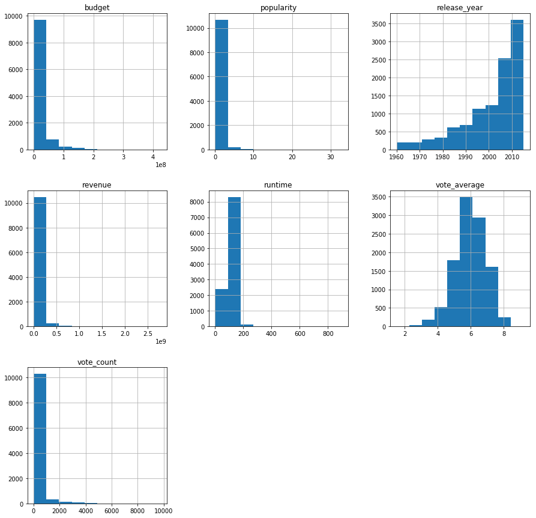

```python
new_df.hist(figsize=(15,15));
```

### Which genres are most popular from year to year?

```python
# Split cells of a column with multiple values and replace them with a column with single values.
genre_spilt = new_df['genres'].str.split('|').apply(pd.Series, 1).stack().reset_index(level = 1, drop = True)
genre_spilt.name = 'new_genres'
new_df_split = new_df.drop(['genres'], axis= 1).join(genre_spilt)
new_df_split['new_genres'].value_counts(dropna = False)
```

```
Drama              4760
Comedy             3793
Thriller           2907
Action             2384
Romance            1712
Horror             1637
Adventure          1471
Crime              1354
Family             1231
Science Fiction    1229
Fantasy             916
Mystery             810
Animation           699
Documentary         520
Music               408
History             334
War                 270
Foreign             188
TV Movie            167
Western             165
NaN                  23
Name: new_genres, dtype: int64
```

### Split the cells of the [genres column] with multiple values and replace it with a [new_genres] column with single values.

```python
# Delete rows in which a date column does not contain data
df_genres = new_df_split.dropna(axis = 0, subset = ['new_genres'])
```

```python
new_genres_mean = new_df_split.groupby('new_genres').popularity.mean()
new_genres_mean
```

```
new_genres
Action             0.926274
Adventure          1.154259
Animation          0.852182
Comedy             0.592607
Crime              0.744930
Documentary        0.181432
Drama              0.591495
Family             0.786668
Fantasy            0.992840
Foreign            0.191496
History            0.575936
Horror             0.465357
Music              0.487321
Mystery            0.690012
Romance            0.592082
Science Fiction    1.001548
TV Movie           0.270896
Thriller           0.741563
War                0.727683
Western            0.590615
Name: popularity, dtype: float64
```

```python
labels = new_genres_mean.index.tolist()
values = new_genres_mean.tolist()
fig = go.Figure(
    go.Pie(
        labels = labels,
        values = values,
        sort = True,
        direction = 'clockwise'
    ),
    go.Layout(
        title = "Genre Movies, 1960:2015"
    )
)
fig.show();
```

[interactive chart not shown]

### Adventure genres had the highest popularity with an average rate of 8.77%, followed by Science Fiction films with 7.61% and Documentaries the least popular with 1.38%

### Film production growth by genre from 1960 to 2015

```python
def move_genre(df,modes,kind):
    data=[]

    for genre in genres_unique:
        new_genres_year = df.query('new_genres == @genre')
        new_genres_year = new_genres_year.groupby(['release_year'])['new_genres'].count()
        l = new_genres_year.index
        m = new_genres_year.values
        data.append (kind(
            x = l,
            y = m,
            mode = modes,
            name = genre
        ))
    return data
```

```python
genres_unique = df_genres['new_genres'].unique()
data = move_genre(new_df_split,'lines',go.Scatter)
layout = go.Layout(title = 'Film production growth by genre from 1960 to 2015', xaxis_title = 'Years', yaxis_title = 'Count')
```

```python
figure = go.Figure(data = data, layout= layout)
figure.show()
```

[interactive chart not shown]

### Drama film genres had the highest productions in 2014, producing 284 films.

### What year were the most films made?

```python
most_year = new_df.groupby('release_year').size()
```

```python
l = most_year.index
m = most_year.values
```

```python
data_year = [go.Bar(
    x = l,
    y = m,
    text = m,
    textposition = "inside"
)]
layout_year = go.Layout(title = 'Year the most films made', xaxis = {"showgrid":False}, yaxis = {"showgrid":False},xaxis_title = 'Years', yaxis_title = 'Number of movies')
```

```python
figure = go.Figure(data = data_year, layout= layout_year)
figure.show()
```

[interactive chart not shown]

### In 2014, the largest number of films were produced with 700 films produced.

### Comparison between the average budget for the year and its profits

```python
# Select the data in which columns A, B do not contain 0 values
df_No_zero = new_df.query('budget != 0 and revenue != 0')
```

```python
budget_mean = df_No_zero.groupby('release_year').budget.mean()
revenue_mean = df_No_zero.groupby('release_year').revenue.mean()
```

```python
l = budget_mean.index
m = budget_mean.values
l2 = revenue_mean.index
m2 = revenue_mean.values
```

```python
data_comparison = [go.Scatter(
    x = l2,
    y = m2,
    mode = 'lines',
    name = 'Revenue Mean'
),
go.Scatter(
    x = l,
    y = m,
    mode = 'lines',
    name = 'Budget Mean'
)]
```

```python
layout_comparison = go.Layout(title = 'Comparison between the average budget for the year and its profits from 1960 to 2015', xaxis_title = 'years', yaxis_title = "Value in millions")
```

```python
figure = go.Figure(data = data_comparison, layout= layout_comparison)
figure.show()
```

[interactive chart not shown]

### What is the relationship between movie popularity and revenue?

```python
revenue_popularity = df_No_zero.groupby('popularity').revenue.mean()
```

```python
l3 = revenue_popularity.index
m3 = revenue_popularity.values
```

```python
popularityVSrevenue =[go.Scatter(
    x = l3,
    y = m3,
    mode = 'markers',
    name = 'Popularity vs Revenue'
)]
```

```python
layout_popularity = go.Layout(title = 'Popularity vs Revenue', xaxis_title = 'Popularity', yaxis_title = 'Revenue')
```

```python
figure = go.Figure(data = popularityVSrevenue, layout= layout_popularity)
figure.show()
```

[interactive chart not shown]

### Which director directed the most films from 1960 to 2015?

```python
new_df['director'].value_counts(dropna = False)
```

```
Woody Allen                                              45
NaN                                                      44
Clint Eastwood                                           34
Steven Spielberg                                         29
Martin Scorsese                                          29
Ridley Scott                                             23
Ron Howard                                               22
Steven Soderbergh                                        22
Joel Schumacher                                          21
Brian De Palma                                           20
Tim Burton                                               19
Wes Craven                                               19
Barry Levinson                                           19
David Cronenberg                                         18
Mike Nichols                                             18
Rob Reiner                                               18
John Carpenter                                           18
Sidney Lumet                                             17
Stephen Frears                                           17
Walter Hill                                              17
Norman Jewison                                           17
Oliver Stone                                             17
Robert Zemeckis                                          17
Renny Harlin                                             17
Tyler Perry                                              17
Francis Ford Coppola                                     17
Spike Lee                                                17
Peter Hyams                                              17
Stephen Herek                                            16
Richard Linklater                                        16
                                                         ..
John Simpson                                              1
Brenda Chapman|Steve Hickner|Simon Wells                  1
Jorge Montesi|Dominique Othenin-Girard                    1
Jacob Vaughan                                             1
Nikita Mikhalkov                                          1
Christophe Gans|Shusuke Kaneko|Brian Yuzna                1
Dick Richards                                             1
J.P. Schaefer                                             1
Emmanuel Mouret                                           1
Andrew Lau                                                1
Robert Rossen                                             1
Ezio Greggio                                              1
Takashi Miike                                             1
Jared Drake                                               1
Joe Begos                                                 1
Ellen Hovde|Muffie Meyer|Albert Maysles|David Maysles     1
Michael Powell                                            1
Robert Moresco                                            1
Brett Morgen                                              1
Tim Johnson|Patrick Gilmore                               1
Bruce Paltrow                                             1
Stevie Wermers                                            1
Carles Torrens                                            1
Eli Morgan Gesner                                         1
Dan Rush                                                  1
David Burris                                              1
Andy GarcÃa                                              1
Benjamin Turner|Gabe Turner                               1
Matt Checkowski|Kurt Mattila                              1
Jean-Paul SalomÃ©|Serge Boutleroff                        1
Name: director, Length: 5068, dtype: int64
```

```python
df_director = new_df.dropna(axis = 0, subset = ['director'])
```

```python
#The director who has directed the most films
director = df_director.groupby('director').size()
num = director.max()
name = director.idxmax()
print("The director who has directed the most films is[ {} ], and he has directed [ {} ] films.".format(name, num))
```

```
The director who has directed the most films is[ Woody Allen ], and he has directed [ 45 ] films.
```

### The director who has directed the most films is Woody Allen , and he has directed 45 films.

### Which company produced the most films from 1960 to 2015?

```python
new_df['production_companies'].value_counts(dropna = False)
```

```
NaN                                                                                                                            1030
Paramount Pictures                                                                                                              156
Universal Pictures                                                                                                              133
Warner Bros.                                                                                                                     84
Walt Disney Pictures                                                                                                             76
Columbia Pictures                                                                                                                72
Metro-Goldwyn-Mayer (MGM)                                                                                                        72
New Line Cinema                                                                                                                  61
Touchstone Pictures                                                                                                              51
20th Century Fox                                                                                                                 50
Twentieth Century Fox Film Corporation                                                                                           49
TriStar Pictures                                                                                                                 45
Orion Pictures                                                                                                                   42
Miramax Films                                                                                                                    32
DreamWorks Animation                                                                                                             31
Columbia Pictures Corporation                                                                                                    31
Pixar Animation Studios                                                                                                          30
Walt Disney Productions                                                                                                          29
Dimension Films                                                                                                                  28
United Artists                                                                                                                   23
Marvel Studios                                                                                                                   22
Imagine Entertainment|Universal Pictures                                                                                         22
The Asylum                                                                                                                       21
Lions Gate Films                                                                                                                 21
New World Pictures                                                                                                               17
Walt Disney Pictures|Pixar Animation Studios                                                                                     17
American International Pictures (AIP)                                                                                            14
Disney Channel                                                                                                                   14
Hammer Film Productions                                                                                                          13
Hollywood Pictures                                                                                                               12
                                                                                                                               ...
Columbia Pictures Corporation|Apatow Productions                                                                                  1
Eden Rock Media                                                                                                                   1
Gigantic Movie|Epoch Films                                                                                                        1
Avenue Pictures Productions|Sandbar Pictures                                                                                      1
BBC Films|Endgame Entertainment|Ealing Studios|Fragile Films|Odyssey Entertainment                                                1
TriStar Pictures|Canal+|Carolco Pictures|RCS Video|Cliffhanger Productions                                                        1
Paramount Pictures|Georgetown Productions Inc.                                                                                    1
New World Pictures|Cinemarque Entertainment                                                                                       1
Twentieth Century Fox Film Corporation|Dune Entertainment|Major Studio Partners|Regency Enterprises|Epsilon Motion Pictures       1
Aldamisa Entertainment|MVP Films|Invest Capital Film Group|Live Screen Pictures                                                   1
```

[output cut: 21 more lines]

```python
df_company = new_df.dropna(axis = 0, subset = ['production_companies'])
```

```python
#The company that produced the largest number of films is
company = df_company.groupby('production_companies').size()
num2 = company.max()
name2 = company.idxmax()
print("The company that produced the largest number of films is[ {} ], and it has produced  [ {} ] films.".format(name2, num2))
```

```
The company that produced the largest number of films is[ Paramount Pictures ], and it has produced  [ 156 ] films.
```

### The company that produced the largest number of films is Paramount Pictures , and it has produced 156 films.

## Conclusions

### Limitations: There are couple of limitations with our data:

1. The data type of the date column is a string
2. The Genres column is in separate data by '|'
3. Number of rows containing Null
4. And also there are a number of rows with irrational values, for example, the budget column has values = 0

### The sources that I used in the project:-

1. Classroom
2. https://stackoverflow.com
3. https://www.w3schools.com
4. https://nfpdiscussions.udacity.com/c/questions-hub/99